# STAT545_ZacharySherker_Homework3

# STAT 545 Homework Assignment 3 ## Zachary Sherker # Overview

In this assignment I will perform the following tasks:

-Get the maximum and minimum of GDP per capita for all continents.

-Compute a trimmed mean of life expectancy for different years.

-Report the absolute and/or relative abundance of countries with low life expectancy over time by continent: Compute some measure of worldwide life expectancy – you decide – a mean or median or some other quantile or perhaps your current age. Then determine how many countries on each continent have a life expectancy less than this benchmark, for each year.

I will first upload gapminder data set, tidy verse, and `knitr` and `reshape 2` packages.

```r
library(gapminder)
library(tidyverse)
library(knitr)
library(reshape2)
```

# Get the maximum and minimum of GDP per capita for all continents. I start by grouping the gapminder dataset by continent and use the summarize function to find max and min GDP per capita values.

```r
group_by(gapminder,continent) %>%
  summarize(max_gdpPercap=max(gdpPercap),min_gdpPercap=min(gdpPercap))
```

```
## # A tibble: 5 x 3
##   continent max_gdpPercap min_gdpPercap
##   <fct>             <dbl>         <dbl>
## 1 Africa           21951.          241.
## 2 Americas         42952.         1202.
## 3 Asia            113523.          331
## 4 Europe           49357.          974.
## 5 Oceania          34435.        10040.
```

```r
a<- group_by(gapminder,continent) %>%
  summarize(max_gdpPercap=max(gdpPercap),min_gdpPercap=min(gdpPercap))
```

I will then visualize and compare the min and max GDP per cap of each continent using a bar graph.

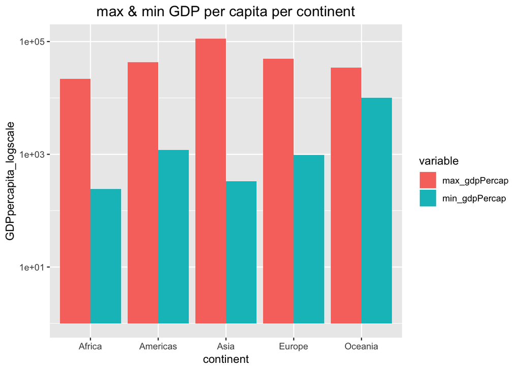

```r
b<-melt(a,id=c("continent"))
ggplot(b,aes(x=continent,y=value,fill=variable))+
  geom_bar(position="dodge",stat="identity")+scale_y_log10()+
  theme(plot.title = element_text(size=14,hjust=0.5))+
  labs(x="continent",
       y="GDPpercapita_logscale",
       title="max & min GDP per capita per continent")
```

# Compute a trimmed mean of life expectancy for different years. Or a weighted mean, weighting by population. Just try something other than the plain vanilla mean. For this analysis I have trimmed the life expectancy of the various years by one standard deviation.

```r
group_by(gapminder,year)%>%
  filter(lifeExp > (mean(lifeExp)-sd(lifeExp)) &
         lifeExp < (mean(lifeExp)+sd(lifeExp)))%>%
         summarize(mean_lifeExp=mean(lifeExp),
                   median_lifeExp=median(lifeExp),
                   sd_lifeExp=sd(lifeExp))
```

```
## # A tibble: 12 x 4
##     year mean_lifeExp median_lifeExp sd_lifeExp
##    <int>        <dbl>          <dbl>      <dbl>
##  1  1952         46.5           43.7       7.43
##  2  1957         48.9           46.0       7.45
##  3  1962         51.8           49.2       7.50
##  4  1967         54.2           52.0       7.06
##  5  1972         57.1           55.6       6.61
##  6  1977         60.5           59.8       6.95
##  7  1982         62.8           62.9       6.41
##  8  1987         64.7           65.9       5.90
##  9  1992         66.2           68.0       6.13
## 10  1997         67.7           69.7       6.56
## 11  2002         69.1           71.0       6.85
## 12  2007         70.4           72.4       6.64
```

I then visualize the trimmed data set through a histogram to see the distribution of life expectancy by country over time from 1952-2007.

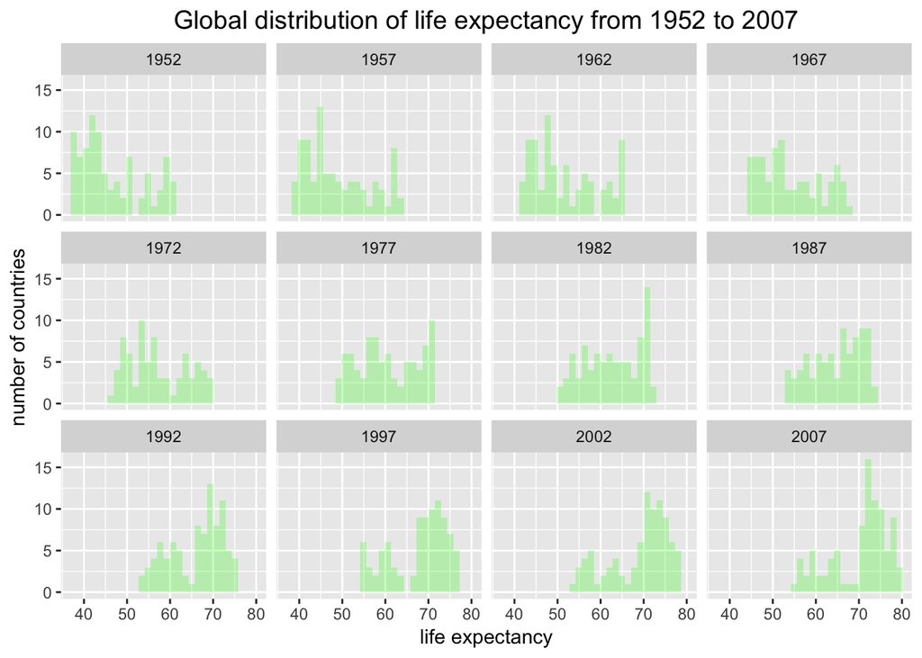

```r
group_by(gapminder,year)%>%
  filter(lifeExp > (mean(lifeExp)-sd(lifeExp)) &
         lifeExp < (mean(lifeExp)+sd(lifeExp)))%>%
  ggplot(aes(x=lifeExp))+
  geom_histogram(fill='green',alpha=0.25)+
  facet_wrap(~year)+
  theme(plot.title = element_text(size=14,hjust=0.5))+
  labs(x="life expectancy",
       y="number of countries",
       title="Global distribution of life expectancy from 1952 to 2007")
```

# Report the absolute abundance of countries with low life expectancy over time by continent I first calculate the global low life expectancy (low life exp = average life exp - the SD of life exp) for each year.

```r
group_by(gapminder,year)%>%
  summarize(low_life_expectancy=mean(lifeExp)-sd(lifeExp))%>%kable()
```

[output not shown]

```r
c<-group_by(gapminder,year)%>%
  mutate(lowLifeExp=mean(lifeExp)-sd(lifeExp))
group_by(c,continent,year)%>%
  summarize(Total_lowLifeExp=sum(lifeExp<lowLifeExp))
```

```
## # A tibble: 60 x 3
## # Groups:   continent [?]
##    continent  year Total_lowLifeExp
##    <fct>     <int>            <int>
##  1 Africa     1952               17
##  2 Africa     1957               19
##  3 Africa     1962               22
##  4 Africa     1967               23
##  5 Africa     1972               25
##  6 Africa     1977               24
##  7 Africa     1982               26
##  8 Africa     1987               28
##  9 Africa     1992               27
## 10 Africa     1997               29
## # ... with 50 more rows
```

```r
d<- group_by(c,continent,year)%>%
  summarize(numBelowLowLifeExp=sum(lifeExp<lowLifeExp))
```

I then used a scatterplot to visualize the number of countries with low life expectancy in each continent per year.

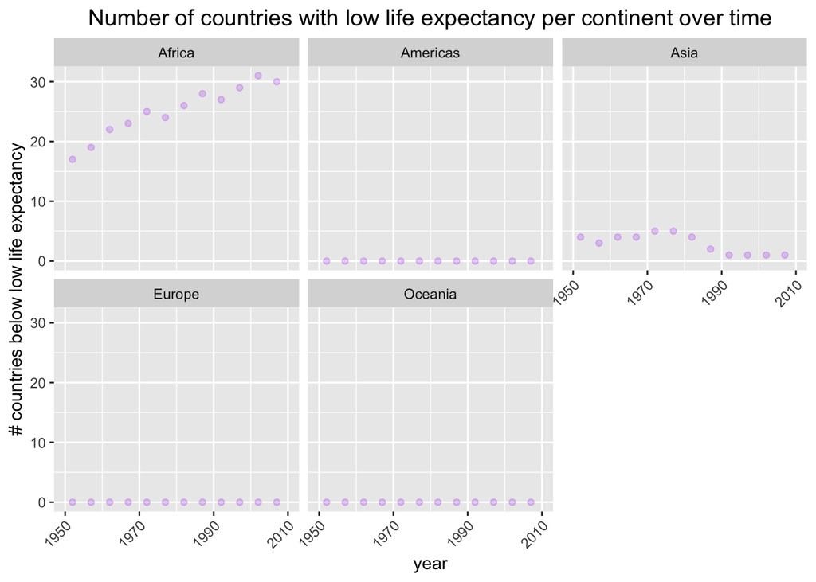

```r
ggplot(d,aes(x=year,y=numBelowLowLifeExp))+
  geom_point(color='purple',alpha=0.2)+
  facet_wrap(~continent)+
  scale_x_continuous(breaks = seq(1950, 2010, 20),
                     labels = as.character(seq(1950, 2010, 20)),
                     limits = c(1950, 2010))+
  theme(axis.text.x = element_text(angle = 45, hjust = 1),
        plot.title = element_text(size=14,hjust=0.5))+
  labs(x="year",
       y="# countries below low life expectancy",
       title="Number of countries with low life expectancy per continent over time")
```